# SBL Survey Analysis

# Supplementary Material Chapter 4

**Author:** Michael S. Feurstein  
**Created:** 15 May 2025  
**Last compiled:** 20 May 2025

## About this notebook

This notebook is a supplementary material for Chapter “Perceived Usability Survey” used for replication of results. Data preparation steps have been done before. All further details on survey design, methodology and analysis procedure can be found in the corresponding Chapter of thesis.

### Libraries

```r
library(dplyr)
if(!require(likert)){install.packages("likert")}
library(likert)
if(!require(svglite)){install.packages("svglite")}
library(svglite)
library(ggplot2)
```

### Load Data

File: *“data_survey_prepared.csv”* - contains calculated sus-score.

```r
# read from prepared csv
df <- read.csv("data-survey-sus_prepared.csv")
```

File: *participant_profiles_anon_prepared.csv* - contains all anonymized data on participants and their profile (self assessed role: author, user, researcher, other and meta data on activity in field: no of videos, no of papers, no of courses etc.)

```r
# read from prepared csv
profiledata <- read.csv("data-survey-profiles_prepared.csv")
```

File: *data-post-hoc_prepared.csv* - contains post-hoc questions

```r
# read from prepared csv
posthocdata <- read.csv("data-post-hoc_prepared.csv")
posthocdata <- head(posthocdata,-1)
```

## Descriptive Statistics

### Participants

#### Profile

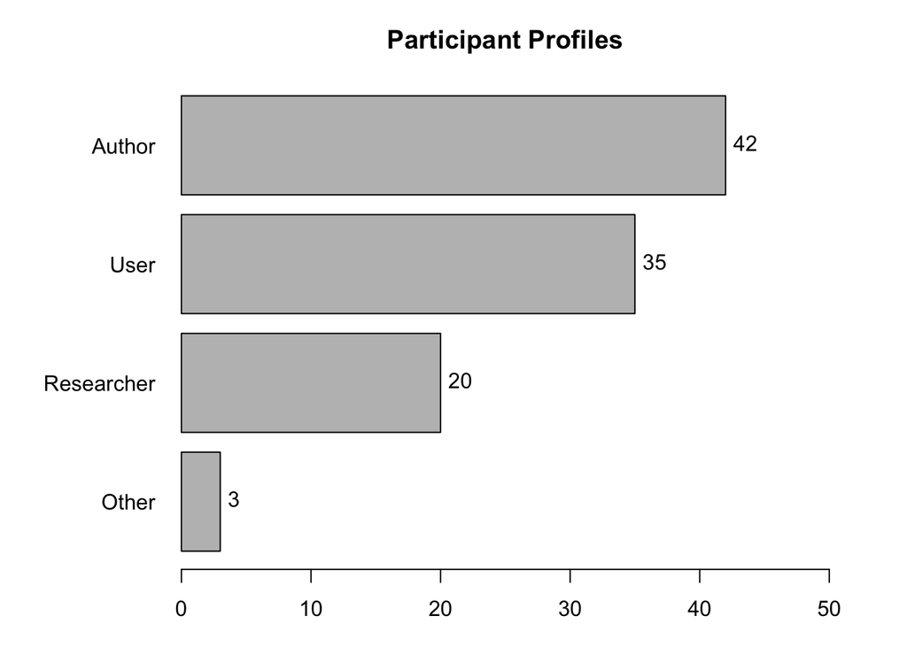

```r
# participant profiles
profileSums <- colSums(profiledata == "Yes")
profile_columns = c("Profile","Frequency")
df_p = data.frame(matrix(nrow = 0, ncol = length(profile_columns)))
colnames(df_p) = profile_columns
df_p[nrow(df_p) + 1,] = c("Author",profileSums["author"])
df_p[nrow(df_p) + 1,] = c("User",profileSums["user"])
df_p[nrow(df_p) + 1,] = c("Researcher",profileSums["researcher"])
df_p[nrow(df_p) + 1,] = c("Other",3) # manual count for profile author:no user:no researcher:no

# convert frequency column into numeric format
df_p$Frequency = as.numeric(as.character(df_p$Frequency))

# order dataframe ascending
# this way it's displayed descending in horizontal barplot
df_p <- df_p[order(df_p$Frequency),]

# plot barplot
counts <- table(df_p$Frequency)
par(mar=c(3, 7, 3, 3))
profile_plot <- barplot(height=df_p$Frequency, names=df_p$Profile, main="Participant Profiles", horiz=T,las=1,xlim=c(0,50),width = c(2,2,2,2,2))
text(x=df_p$Frequency, profile_plot, labels = paste(df_p$Frequency), pos=4, offset=0.3, xpd=T)
```

#### Profile Details

```r
# Author
## Years active
## How many years have you been authoring / producing educational videos, lecture
## recordings or other video-based learning content?
profiledata$authorHOWMANYYEARS <- as.numeric(as.character(profiledata$authorHOWMANYYEARS))
summary(na.omit(profiledata$authorHOWMANYYEARS))
```

```
##    Min. 1st Qu.  Median    Mean 3rd Qu.    Max.
##   1.000   2.250   6.000   7.119   8.000  20.000
```

```r
## Videos created
## How many educational videos, lecture recordings or other video-based learning
## content have you produced until now?
profiledata$authorHOWMANYVIDEOS <- as.numeric(as.character(profiledata$authorHOWMANYVIDEOS))
summary(na.omit(profiledata$authorHOWMANYVIDEOS))
```

```
##    Min. 1st Qu.  Median    Mean 3rd Qu.    Max.
##     1.0    10.0    20.0   113.3    65.0  2000.0
```

```r
# User
## Years active
## How many years have you been using video-based learning content?
profiledata$userHOWMANYYEARS <- as.numeric(as.character(profiledata$userHOWMANYYEARS))
summary(na.omit(profiledata$userHOWMANYYEARS))
```

```
##    Min. 1st Qu.  Median    Mean 3rd Qu.    Max.
##   1.000   5.000  10.000   9.914  15.000  25.000
```

```r
## Courses
## How many courses have you tought with the support of video-based learning con-
## tent? Please also count recurring courses, which possibly took place each semester.
profiledata$userHOWMANYCOURSES <- as.numeric(as.character(profiledata$userHOWMANYCOURSES))
summary(na.omit(profiledata$userHOWMANYCOURSES))
```

```
##    Min. 1st Qu.  Median    Mean 3rd Qu.    Max.
##    0.00    2.00    5.00   20.34   17.50  200.00
```

```r
# Researcher
## Years researching
## How many years have you conducted research in the field of video-based learning
## / technology enhanced learning / educational technology?
profiledata$researchHOWMANYYEARS <- as.numeric(as.character(profiledata$researchHOWMANYYEARS))
summary(na.omit(profiledata$researchHOWMANYYEARS))
```

```
##    Min. 1st Qu.  Median    Mean 3rd Qu.    Max.
##    1.00    2.75    6.00    7.05   10.00   16.00
```

```r
## Papers published
## How many papers have you published in the field of video-based learning?
profiledata$researchHOWMANYPUB <- as.numeric(as.character(profiledata$researchHOWMANYPUB))
summary(na.omit(profiledata$researchHOWMANYPUB))
```

```
##    Min. 1st Qu.  Median    Mean 3rd Qu.    Max.
##    0.00    0.00    1.00    2.80    2.25   22.00
```

### Dependent Variables

#### Usability (SUS Score)

**Boxplot:** Visual inspection of data, using a boxplot.

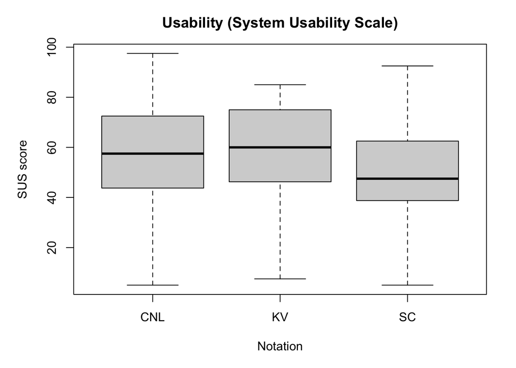

```r
par(mar=c(5, 5, 3, 2))
boxplot(sus ~ notation, data = df, main = "Usability (System Usability Scale)", xlab = "Notation", ylab = "SUS score", names = c("CNL","KV","SC"))
```

**Summary:** For reporting of mean (min, q1, mdn, q2, max) and sd:

```r
df %>%
  group_by(notation) %>%
  summarize(mean = mean(sus), sd = sd(sus), min = min(sus), max = max(sus), med = median(sus), q1 = quantile(sus, 0.25), q3 = quantile(sus, 0.75))
```

```
## # A tibble: 3 × 8
##   notation  mean    sd   min   max   med    q1    q3
##   <chr>    <dbl> <dbl> <dbl> <dbl> <dbl> <dbl> <dbl>
## 1 cnl       56.3  21.1   5    97.5  57.5  43.8  72.5
## 2 kv        58    19.6   7.5  85    60    46.2  75
## 3 sc        49.7  18.2   5    92.5  47.5  38.8  62.5
```

**Mean Difference:** For reporting of unstandardized mean difference:

```r
##### mean difference ####
# values
sus_cnl <- mean(df$sus[df$notation == "cnl"])
sus_kv <- mean(df$sus[df$notation == "kv"])
sus_sc <- mean(df$sus[df$notation == "sc"])
# difference between cnl kv: cnl-kv
sus_diffcnlkv <- sus_cnl-sus_kv
# avergae of nl kv
sus_avgcnlkv <- (sus_cnl+sus_kv)/2
sus_ratiocnlkv <- sus_diffcnlkv/sus_avgcnlkv
# percentage
sus_percent_diff_cnlkv <- abs(sus_ratiocnlkv*100)
print(c("CNL/KV mean difference in percentage: ", sus_percent_diff_cnlkv))
```

```
## [1] "CNL/KV mean difference in percentage: "
## [2] "2.94234592445328"
```

```r
# difference between sc kv: sc-kv
sus_diffsckv <- sus_sc-sus_kv
# avergae of nl kv
sus_avgsckv <- (sus_sc+sus_kv)/2
sus_ratiosckv <- sus_diffsckv/sus_avgsckv
# percentage
sus_percent_diff_sckv <- abs(sus_ratiosckv*100)
print(c("SC/KV mean difference in percentage: ", sus_percent_diff_sckv))
```

```
## [1] "SC/KV mean difference in percentage: "
## [2] "15.4495567750106"
```

### Post-hoc Questions

The following questions were asked after assessing the perceived usability for all three notations.

Preparing for likert plotting

```r
# get the sums of each column with likert levels
strong_disagree <- colSums(posthocdata == "1")
strong_disagree <- as.data.frame(strong_disagree)

disagree <- colSums(posthocdata == "2")
disagree <- as.data.frame(disagree)

neutral <- colSums(posthocdata == "3")
neutral <- as.data.frame(neutral)

agree <- colSums(posthocdata == "4")
agree <- as.data.frame(agree)

strong_agree <- colSums(posthocdata == "5")
strong_agree <- as.data.frame(strong_agree)
```

#### Claim: Efficiency of a text-based approach

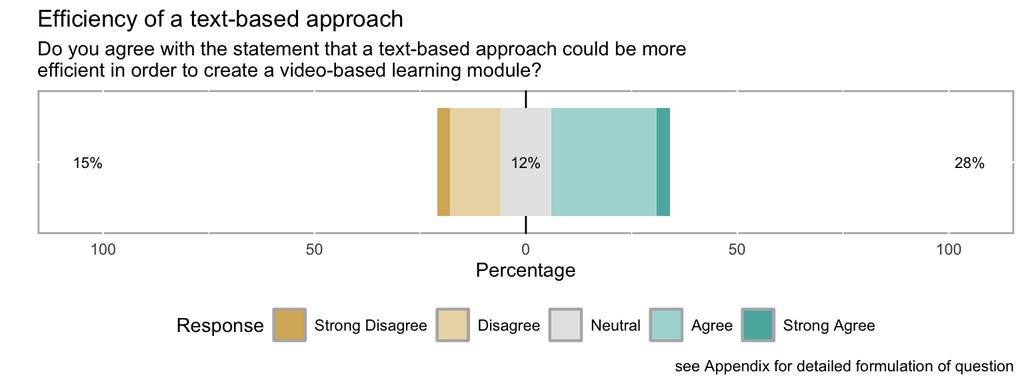

```r
# setup
col_titles = c("Item","Strong Disagree","Disagree","Neutral","Agree","Strong Agree")
df_posthoc_q1 = data.frame(matrix(nrow = 0, ncol = length(col_titles)))
colnames(df_posthoc_q1) = col_titles

# fill
df_posthoc_q1[1, ] <- c("claim.efficiency",strong_disagree[5,],disagree[5,],neutral[5,],agree[5,],strong_agree[5,])

# convert to numeric
i <- c(2:6)
df_posthoc_q1[, i] <- apply(df_posthoc_q1[, i], 2, function(x) as.numeric(as.character(x)))
#sapply(df_posthoc_q1, mode)

# plot
title <- "Efficiency of a text-based approach"
subtitle <- "Do you agree with the statement that a text-based approach could be more\nefficient in order to create a video-based learning module?"
plot(likert(summary = df_posthoc_q1)) +
  labs(title = title, subtitle = subtitle, y = "Percentage", caption = "see Appendix for detailed formulation of question") +
  theme(axis.text.y = element_blank())
```

```r
#save in variable image to export to svg
image=plot(likert(summary = df_posthoc_q1)) +
  labs(title = title, subtitle = subtitle, y = "Percentage", caption = "see Appendix for detailed formulation of question") +
  theme(axis.text.y = element_blank())
#save
ggsave(file="plots/posthoc_q1_efficiency.svg", plot=image, width=8, height=3)
```

#### Claim: Effectiveness of a text-based approach

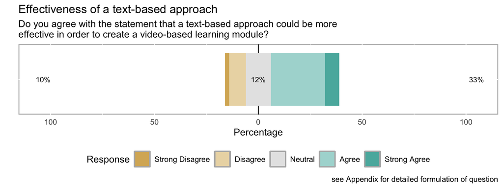

```r
# setup
col_titles = c("Item","Strong Disagree","Disagree","Neutral","Agree","Strong Agree")
df_posthoc_q2 = data.frame(matrix(nrow = 0, ncol = length(col_titles)))
colnames(df_posthoc_q2) = col_titles

# fill
df_posthoc_q2[1, ] <- c("claim.effectiveness",strong_disagree[6,],disagree[6,],neutral[6,],agree[6,],strong_agree[6,])

# convert to numeric
i <- c(2:6)
df_posthoc_q2[, i] <- apply(df_posthoc_q2[, i], 2, function(x) as.numeric(as.character(x)))
#sapply(df_posthoc_q2, mode)

# plot
title <- "Effectiveness of a text-based approach"
subtitle <- "Do you agree with the statement that a text-based approach could be more\neffective in order to create a video-based learning module?"
plot(likert(summary = df_posthoc_q2)) +
  labs(title = title, subtitle = subtitle, y = "Percentage", caption = "see Appendix for detailed formulation of question") +
  theme(axis.text.y = element_blank())
```

```r
#save in variable image to export to svg
image=plot(likert(summary = df_posthoc_q2)) +
  labs(title = title, subtitle = subtitle, y = "Percentage", caption = "see Appendix for detailed formulation of question") +
  theme(axis.text.y = element_blank())
#save
ggsave(file="plots/posthoc_q2_effectiveness.svg", plot=image, width=8, height=3)
```

#### Claim: text as first step

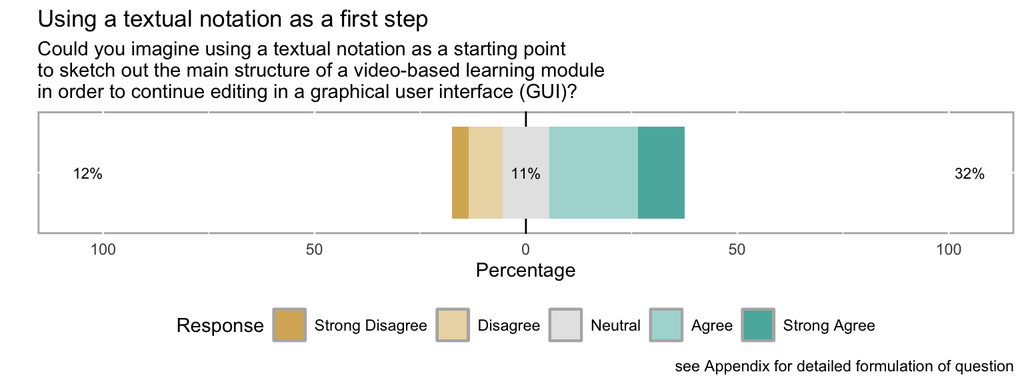

```r
# setup
col_titles = c("Item","Strong Disagree","Disagree","Neutral","Agree","Strong Agree")
df_posthoc_q3 = data.frame(matrix(nrow = 0, ncol = length(col_titles)))
colnames(df_posthoc_q3) = col_titles

# fill
df_posthoc_q3[1, ] <- c("claim.effectiveness",strong_disagree[7,],disagree[7,],neutral[7,],agree[7,],strong_agree[7,])

# convert to numeric
i <- c(2:6)
df_posthoc_q3[, i] <- apply(df_posthoc_q3[, i], 2, function(x) as.numeric(as.character(x)))
#sapply(df_posthoc_q3, mode)

# plot
title <- "Using a textual notation as a first step"
subtitle <- "Could you imagine using a textual notation as a starting point\nto sketch out the main structure of a video-based learning module\nin order to continue editing in a graphical user interface (GUI)?"
plot(likert(summary = df_posthoc_q3)) +
  labs(title = title, subtitle = subtitle, y = "Percentage", caption = "see Appendix for detailed formulation of question") +
  theme(axis.text.y = element_blank())
```

```r
#save in variable image to export to svg
image=plot(likert(summary = df_posthoc_q3)) +
  labs(title = title, subtitle = subtitle, y = "Percentage", caption = "see Appendix for detailed formulation of question") +
  theme(axis.text.y = element_blank())
#save
ggsave(file="plots/posthoc_q3_text-first-step.svg", plot=image, width=8, height=3)
```

#### Claim: text with GUI

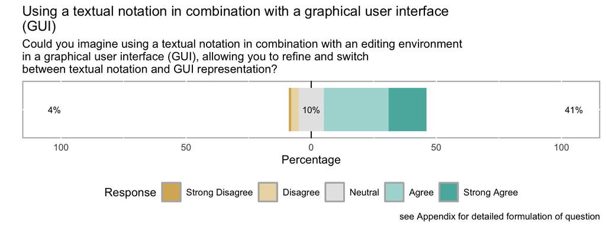

```r
# setup
col_titles = c("Item","Strong Disagree","Disagree","Neutral","Agree","Strong Agree")
df_posthoc_q4 = data.frame(matrix(nrow = 0, ncol = length(col_titles)))
colnames(df_posthoc_q4) = col_titles

# fill
df_posthoc_q4[1, ] <- c("claim.effectiveness",strong_disagree[8,],disagree[8,],neutral[8,],agree[8,],strong_agree[8,])

# convert to numeric
i <- c(2:6)
df_posthoc_q4[, i] <- apply(df_posthoc_q4[, i], 2, function(x) as.numeric(as.character(x)))
#sapply(df_posthoc_q4, mode)

# plot
title <- "Using a textual notation in combination with a graphical user interface
(GUI)"
subtitle <- "Could you imagine using a textual notation in combination with an editing environment\nin a graphical user interface (GUI), allowing you to refine and switch\nbetween textual notation and GUI representation?"
plot(likert(summary = df_posthoc_q4)) +
  labs(title = title, subtitle = subtitle, y = "Percentage", caption = "see Appendix for detailed formulation of question") +
  theme(axis.text.y = element_blank())
```

```r
#save in variable image to export to svg
image=plot(likert(summary = df_posthoc_q4)) +
  labs(title = title, subtitle = subtitle, y = "Percentage", caption = "see Appendix for detailed formulation of question") +
  theme(axis.text.y = element_blank())
#save
ggsave(file="plots/posthoc_q4_text-with-gui.svg", plot=image, width=8, height=3)
```

## Results and Hypothesis Tests

### Tests of Normality

#### Usability (SUS Score)

Two types of visual inspections (histograms and qq-plots) and two types of statistical tests (Shapiro-Wilk and Skewness-Test).

```r
# boxcox transform sus
df$sus.boxcox = (df$sus^3.2-1)/3.2
```